# Exploratory Data Analysis - Assignment 01

You should complete this Jupyter Notebook with your answers. You may need to write code or add explanatory notes.

dataset link: https://www.kaggle.com/datasets/utkarshx27/movies-dataset

```python
# Importing packages and install kaggle package for downloading dataset
import pandas as pd
import numpy as np
import matplotlib.pyplot as plt
import seaborn as sns
import matplotlib.pyplot as plt
import os
import zipfile

# Install Kaggle
%pip install kaggle

# Create a folder to store the dataset
folder_name = 'movies_dataset'
os.makedirs(folder_name, exist_ok=True)

# Download dataset from Kaggle
!kaggle datasets download -d utkarshx27/movies-dataset -p {folder_name}

# Unzip the dataset into the folder
zip_path = f"{folder_name}/movies-dataset.zip"
with zipfile.ZipFile(zip_path, 'r') as zip_ref:
    zip_ref.extractall(folder_name)
```

```python
# Load and print head of the dataset
df = pd.read_csv(f"./{folder_name}/movie_dataset.csv")
df.head()
```

|  | index | budget | genres | homepage | id | keywords | original_language | original_title | overview | popularity | ... | runtime | spoken_languages | status | tagline | title | vote_average | vote_count | cast | crew | director |
| --- | --- | --- | --- | --- | --- | --- | --- | --- | --- | --- | --- | --- | --- | --- | --- | --- | --- | --- | --- | --- | --- |
| 0 | 0 | 237000000 | Action Adventure Fantasy Science Fiction | http://www.avatarmovie.com/ | 19995 | culture clash future space war space colony so... | en | Avatar | In the 22nd century, a paraplegic Marine is di... | 150.437577 | ... | 162.0 | [{"iso_639_1": "en", "name": "English"}, {"iso... | Released | Enter the World of Pandora. | Avatar | 7.2 | 11800 | Sam Worthington Zoe Saldana Sigourney Weaver S... | [{'name': 'Stephen E. Rivkin', 'gender': 0, 'd... | James Cameron |
| 1 | 1 | 300000000 | Adventure Fantasy Action | http://disney.go.com/disneypictures/pirates/ | 285 | ocean drug abuse exotic island east india trad... | en | Pirates of the Caribbean: At World's End | Captain Barbossa, long believed to be dead, ha... | 139.082615 | ... | 169.0 | [{"iso_639_1": "en", "name": "English"}] | Released | At the end of the world, the adventure begins. | Pirates of the Caribbean: At World's End | 6.9 | 4500 | Johnny Depp Orlando Bloom Keira Knightley Stel... | [{'name': 'Dariusz Wolski', 'gender': 2, 'depa... | Gore Verbinski |
| 2 | 2 | 245000000 | Action Adventure Crime | http://www.sonypictures.com/movies/spectre/ | 206647 | spy based on novel secret agent sequel mi6 | en | Spectre | A cryptic message from Bond’s past sends him o... | 107.376788 | ... | 148.0 | [{"iso_639_1": "fr", "name": "Fran\u00e7ais"},... | Released | A Plan No One Escapes | Spectre | 6.3 | 4466 | Daniel Craig Christoph Waltz L\u00e9a Seydoux ... | [{'name': 'Thomas Newman', 'gender': 2, 'depar... | Sam Mendes |
| 3 | 3 | 250000000 | Action Crime Drama Thriller | http://www.thedarkknightrises.com/ | 49026 | dc comics crime fighter terrorist secret ident... | en | The Dark Knight Rises | Following the death of District Attorney Harve... | 112.312950 | ... | 165.0 | [{"iso_639_1": "en", "name": "English"}] | Released | The Legend Ends | The Dark Knight Rises | 7.6 | 9106 | Christian Bale Michael Caine Gary Oldman Anne ... | [{'name': 'Hans Zimmer', 'gender': 2, 'departm... | Christopher Nolan |
| 4 | 4 | 260000000 | Action Adventure Science Fiction | http://movies.disney.com/john-carter | 49529 | based on novel mars medallion space travel pri... | en | John Carter | John Carter is a war-weary, former military ca... | 43.926995 | ... | 132.0 | [{"iso_639_1": "en", "name": "English"}] | Released | Lost in our world, found in another. | John Carter | 6.1 | 2124 | Taylor Kitsch Lynn Collins Samantha Morton Wil... | [{'name': 'Andrew Stanton', 'gender': 2, 'depa... | Andrew Stanton |

5 rows × 24 columns

```python
print(df.columns)
```

```
Index(['index', 'budget', 'genres', 'homepage', 'id', 'keywords',
       'original_language', 'original_title', 'overview', 'popularity',
       'production_companies', 'production_countries', 'release_date',
       'revenue', 'runtime', 'spoken_languages', 'status', 'tagline', 'title',
       'vote_average', 'vote_count', 'cast', 'crew', 'director'],
      dtype='object')
```

## Question 1: Challenges in Analyzing Multiple Genres

In this dataset, each movie can have a mix of multiple genres. What challenges does this pose when analyzing the data, and what approaches do you suggest to manage it?

**Hint:** Consider how multi-label data differs from single-label data in analysis and visualization.

## Answer for question 1

Analyzing movies with multiple genres introduces several challenges. First, simple genre counts become misleading since each movie may belong to multiple genres, causing the total genre count to exceed the actual number of films. Additionally, genres are not independent—some commonly co-occur, like action and adventure—which complicates statistical analysis and modeling. Visualizations like bar charts or histograms lose clarity, requiring more complex tools such as co-occurrence heatmaps or network graphs.From a modeling perspective, traditional single-label classification techniques are insufficient. Specialized methods like One-Hot or Multi-Hot Encoding, Classifier Chains, or Label Powerset are needed to handle multi-label data effectively. To address these challenges, it’s essential to use relative frequencies, explore genre relationships through correlation or association analysis, and apply machine learning models designed for multi-label classification, such as multi-label SVMs or neural networks.

## Question 2: Missing Keywords Analysis

What percentage of movies are missing keywords? In what systems could this be a problem? What methods do you suggest to complete this incomplete data?

**Hint:** Identify missing values and think about how they might impact recommendation systems or search functionalities.

```python
# Write your answer here:
```

```python
RF = df['keywords'].isna().sum() / len(df)
print(RF*100)
```

```
8.577972100770353
```

Missing keywords can impact several systems, particularly those that rely on metadata for functionality. Recommendation systems, especially content-based filtering models, depend on keywords to identify similar movies, and missing keywords can reduce their effectiveness in suggesting relevant films. Search and filtering platforms, use keywords for tag-based searches missing keywords data can lead to poor search results and make some movies harder to find. Additionally, machine learning models that use keywords as features for movie classification or genre prediction may suffer from biases or inaccuracies in training and predictions due to missing values. To complete missing keyword data, two main approaches can be used: rewriting keywords based on detailed movie information, such as the overview, or leveraging keywords from similar movies through an algorithmic approach.

## Question 3: Correlation Between Budget and Popularity

Do you think there is a strong correlation between a film’s budget and its popularity? Use a graph or statistical calculations to explore this relationship and interpret the results.

**Hint:** A scatter plot and correlation coefficient might help in identifying the relationship.

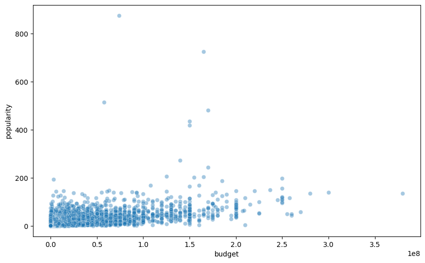

OLS Regression Results

| Dep. Variable: | popularity | R-squared: | 0.255 |
| --- | --- | --- | --- |
| Model: | OLS | Adj. R-squared: | 0.255 |
| Method: | Least Squares | F-statistic: | 1647. |
| Date: | Thu, 27 Mar 2025 | Prob (F-statistic): | 7.05e-310 |
| Time: | 11:07:31 | Log-Likelihood: | -22725. |
| No. Observations: | 4803 | AIC: | 4.545e+04 |
| Df Residuals: | 4801 | BIC: | 4.547e+04 |
| Df Model: | 1 |  |  |
| Covariance Type: | nonrobust |  |  |

|  | coef | std err | t | P>\|t\| | [0.025 | 0.975] |
| --- | --- | --- | --- | --- | --- | --- |
| const | 10.0229 | 0.487 | 20.596 | 0.000 | 9.069 | 10.977 |
| budget | 3.949e-07 | 9.73e-09 | 40.585 | 0.000 | 3.76e-07 | 4.14e-07 |

| Omnibus: | 8450.438 | Durbin-Watson: | 1.731 |
| --- | --- | --- | --- |
| Prob(Omnibus): | 0.000 | Jarque-Bera (JB): | 16581973.792 |
| Skew: | 12.157 | Prob(JB): | 0.00 |
| Kurtosis: | 289.822 | Cond. No. | 6.14e+07 |

Notes:  
[1] Standard Errors assume that the covariance matrix of the errors is correctly specified.  
[2] The condition number is large, 6.14e+07. This might indicate that there are  
strong multicollinearity or other numerical problems.

```python
import pandas as pd
import numpy as np
import statsmodels.api as sm
from scipy.stats import spearmanr
from sklearn.linear_model import LinearRegression
df = df.dropna(subset=['budget', 'popularity'])
X = df[['budget']]
y = df['popularity']
plt.figure(figsize=(10, 6))
sns.scatterplot(x=df['budget'], y=df['popularity'], alpha=0.4)
plt.show()
X1 = sm.add_constant(X)
ols_model = sm.OLS(y, X1).fit()
ols_model.summary()
```

## Question 4: Visualizing Popularity of Different Genres

What type of graph would you use to show the popularity of different genres, and why?

I would ratther use Barplot because it effectively visualizes the comparison of mean popularity across different movie genres

```python
df['genres'] = df['genres'].astype(str)
df = df.dropna(subset=['genres', 'popularity'])
df['genres'] = df['genres'].str.split()
df_exploded = df.explode('genres')
df_exploded['genres'] = df_exploded['genres'].str.replace("'", "").str.replace("]", "").str.replace("[", "").str.replace(",","").str.strip()
df_exploded = df_exploded.reset_index(drop=True)
df_exploded.head()
```

|  | index | budget | genres | homepage | id | keywords | original_language | original_title | overview | popularity | ... | runtime | spoken_languages | status | tagline | title | vote_average | vote_count | cast | crew | director |
| --- | --- | --- | --- | --- | --- | --- | --- | --- | --- | --- | --- | --- | --- | --- | --- | --- | --- | --- | --- | --- | --- |
| 0 | 0 | 237000000 | Action | http://www.avatarmovie.com/ | 19995 | culture clash future space war space colony so... | en | Avatar | In the 22nd century, a paraplegic Marine is di... | 150.437577 | ... | 162.0 | [{"iso_639_1": "en", "name": "English"}, {"iso... | Released | Enter the World of Pandora. | Avatar | 7.2 | 11800 | Sam Worthington Zoe Saldana Sigourney Weaver S... | [{'name': 'Stephen E. Rivkin', 'gender': 0, 'd... | James Cameron |
| 1 | 0 | 237000000 | Adventure | http://www.avatarmovie.com/ | 19995 | culture clash future space war space colony so... | en | Avatar | In the 22nd century, a paraplegic Marine is di... | 150.437577 | ... | 162.0 | [{"iso_639_1": "en", "name": "English"}, {"iso... | Released | Enter the World of Pandora. | Avatar | 7.2 | 11800 | Sam Worthington Zoe Saldana Sigourney Weaver S... | [{'name': 'Stephen E. Rivkin', 'gender': 0, 'd... | James Cameron |
| 2 | 0 | 237000000 | Fantasy | http://www.avatarmovie.com/ | 19995 | culture clash future space war space colony so... | en | Avatar | In the 22nd century, a paraplegic Marine is di... | 150.437577 | ... | 162.0 | [{"iso_639_1": "en", "name": "English"}, {"iso... | Released | Enter the World of Pandora. | Avatar | 7.2 | 11800 | Sam Worthington Zoe Saldana Sigourney Weaver S... | [{'name': 'Stephen E. Rivkin', 'gender': 0, 'd... | James Cameron |
| 3 | 0 | 237000000 | Science | http://www.avatarmovie.com/ | 19995 | culture clash future space war space colony so... | en | Avatar | In the 22nd century, a paraplegic Marine is di... | 150.437577 | ... | 162.0 | [{"iso_639_1": "en", "name": "English"}, {"iso... | Released | Enter the World of Pandora. | Avatar | 7.2 | 11800 | Sam Worthington Zoe Saldana Sigourney Weaver S... | [{'name': 'Stephen E. Rivkin', 'gender': 0, 'd... | James Cameron |
| 4 | 0 | 237000000 | Fiction | http://www.avatarmovie.com/ | 19995 | culture clash future space war space colony so... | en | Avatar | In the 22nd century, a paraplegic Marine is di... | 150.437577 | ... | 162.0 | [{"iso_639_1": "en", "name": "English"}, {"iso... | Released | Enter the World of Pandora. | Avatar | 7.2 | 11800 | Sam Worthington Zoe Saldana Sigourney Weaver S... | [{'name': 'Stephen E. Rivkin', 'gender': 0, 'd... | James Cameron |

5 rows × 24 columns

```
genres
Adventure      39.268042
Animation      38.813439
Science        36.687578
Fiction        36.687578
Fantasy        36.264931
Action         30.946458
Family         27.697398
Mystery        24.633701
Thriller       24.539042
War            23.753500
Crime          22.853274
Western        18.403803
Horror         18.295915
Comedy         18.221001
Drama          17.764853
History        17.444839
Romance        15.876695
Music          13.170565
TV              6.389415
Movie           6.389415
Documentary     3.945724
Foreign         0.686787
Name: popularity, dtype: float64
```

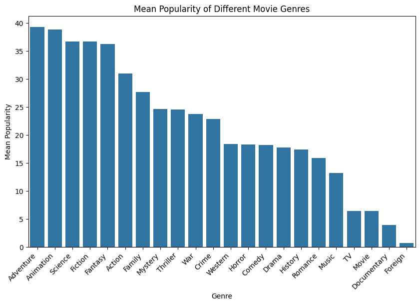

```python
df_exploded = df_exploded[df_exploded['genres'].str.lower() != "nan"]  # Drop string-based 'nan'
genre_popularity_mean = df_exploded.groupby('genres')['popularity'].mean().sort_values(ascending=False)
print(genre_popularity_mean)
plt.figure(figsize=(10, 6))
sns.barplot(x=genre_popularity_mean.index, y=genre_popularity_mean.values)
plt.xticks(rotation=45, ha='right')
plt.xlabel("Genre")
plt.ylabel("Mean Popularity")
plt.title("Mean Popularity of Different Movie Genres")
plt.show()
```

## Question 5: Analyzing Average Movie Budget

How would you calculate the average budget for movies, and what insights can this provide? Calculate the mean budget for all movies and visualize the distribution using an appropriate plot. Explain any trends or patterns you observe.

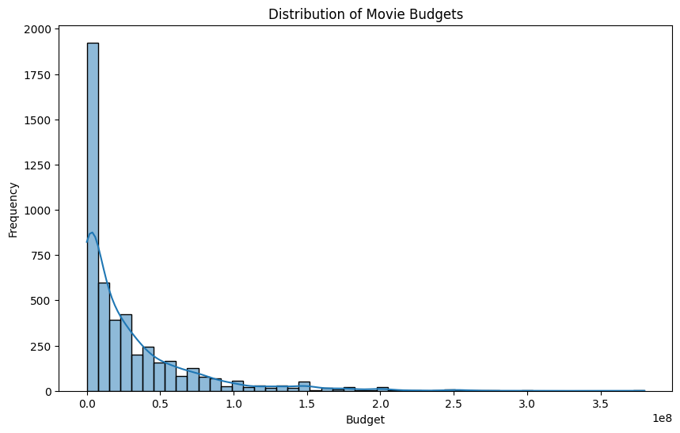

```python
# Write your answer here:
plt.figure(figsize=(10, 6))
sns.histplot(df['budget'], bins=50, kde=True)
plt.title('Distribution of Movie Budgets')
plt.xlabel('Budget')
plt.ylabel('Frequency')
plt.show()
```

```python
print(df['budget'].mean())
```

```
29045039.87528628
```

The average movie budget is approximately $29 million, The distribution of movie budgets follows an exponential-like (right-skewed) distribution, where most values are concentrated at the lower end, and fewer movies have extremely high budgets.

## Question 6: Identifying Directors with the Highest Average Movie Budget

Which director has the highest mean budget for their movies, and how would you determine this?

```python
# Write your answer here:
df_clean = df.dropna(subset=['director', 'budget'])
director_avg_budget = df_clean.groupby('director')['budget'].mean()
director_avg_budget.sort_values(ascending=False).head(1)
```

```
director
Byron Howard    260000000.0
Name: budget, dtype: float64
```

## Question 7: Exploring the Relationship Between Genre and Revenue

First, calculate the revenue-to-budget ratio for all movies and identify the top 100 movies with the highest ratios. Then, analyze whether there is a meaningful relationship between genre and revenue in these movies. Use appropriate statistical methods or visualizations to support your findings.

```python
# Write your answer here:
df_ratio = df_exploded[(df_exploded['budget'] > 0) & (df_exploded['revenue'] > 0)].copy()
df_ratio['ratio'] = df_ratio['revenue'] / df_ratio['budget']
df_ratio = df_ratio.sort_values('ratio', ascending=False).head(100)
df_ratio
```

|  | index | budget | genres | homepage | id | keywords | original_language | original_title | overview | popularity | ... | spoken_languages | status | tagline | title | vote_average | vote_count | cast | crew | director | ratio |
| --- | --- | --- | --- | --- | --- | --- | --- | --- | --- | --- | --- | --- | --- | --- | --- | --- | --- | --- | --- | --- | --- |
| 11504 | 4238 | 1 | Drama | NaN | 3082 | factory ambulance invention tramp great depres... | en | Modern Times | The Tramp struggles to live in modern industri... | 28.276480 | ... | [{"iso_639_1": "en", "name": "English"}] | Released | He stands alone as the greatest entertainer of... | Modern Times | 8.1 | 856 | Charlie Chaplin Paulette Goddard Henry Bergman... | [{'name': 'Charles D. Hall', 'gender': 2, 'dep... | Charlie Chaplin | 8.500000e+06 |
| 11505 | 4238 | 1 | Comedy | NaN | 3082 | factory ambulance invention tramp great depres... | en | Modern Times | The Tramp struggles to live in modern industri... | 28.276480 | ... | [{"iso_639_1": "en", "name": "English"}] | Released | He stands alone as the greatest entertainer of... | Modern Times | 8.1 | 856 | Charlie Chaplin Paulette Goddard Henry Bergman... | [{'name': 'Charles D. Hall', 'gender': 2, 'dep... | Charlie Chaplin | 8.500000e+06 |
| 8914 | 3137 | 10 | Horror | NaN | 78383 | nurse sexual murder revenge lesbian relationsh... | en | Nurse 3-D | Abby Russell, a beautiful, dedicated nurse wit... | 10.013629 | ... | [{"iso_639_1": "en", "name": "English"}] | Released | Your pain is her pleasure. | Nurse 3-D | 4.9 | 119 | Paz de la Huerta Katrina Bowden Kathleen Turne... | [{'name': 'David Loughery', 'gender': 2, 'depa... | Douglas Aarniokoski | 1.000000e+06 |
| 8915 | 3137 | 10 | Thriller | NaN | 78383 | nurse sexual murder revenge lesbian relationsh... | en | Nurse 3-D | Abby Russell, a beautiful, dedicated nurse wit... | 10.013629 | ... | [{"iso_639_1": "en", "name": "English"}] | Released | Your pain is her pleasure. | Nurse 3-D | 4.9 | 119 | Paz de la Huerta Katrina Bowden Kathleen Turne... | [{'name': 'David Loughery', 'gender': 2, 'depa... | Douglas Aarniokoski | 1.000000e+06 |
| 12229 | 4577 | 15000 | Horror | http://www.paranormalactivity-movie.com/ | 23827 | haunting psychic entity demonic possession fou... | en | Paranormal Activity | After a young, middle class couple moves into ... | 47.456823 | ... | [{"iso_639_1": "en", "name": "English"}] | Released | What Happens When You Sleep? | Paranormal Activity | 5.9 | 1316 | Katie Featherston Micah Sloat Mark Fredrichs A... | [{'name': 'Jason Blum', 'gender': 2, 'departme... | Oren Peli | 1.289039e+04 |
| ... | ... | ... | ... | ... | ... | ... | ... | ... | ... | ... | ... | ... | ... | ... | ... | ... | ... | ... | ... | ... | ... |
| 12668 | 4796 | 7000 | Fiction | http://www.primermovie.com | 14337 | distrust garage identity crisis time travel ti... | en | Primer | Friends/fledgling entrepreneurs invent a devic... | 23.307949 | ... | [{"iso_639_1": "en", "name": "English"}] | Released | What happens if it actually works? | Primer | 6.9 | 658 | Shane Carruth David Sullivan Casey Gooden Anan... | [{'name': 'Shane Carruth', 'gender': 2, 'depar... | Shane Carruth | 6.068000e+01 |
| 10701 | 3889 | 3000000 | Horror | http://www.paranormalmovie.com/trailer/ | 41436 | ouija board haunting demonic possession found ... | en | Paranormal Activity 2 | Just as Dan and Kristi welcome a newborn baby ... | 22.789649 | ... | [{"iso_639_1": "en", "name": "English"}] | Released | In 2009 you demanded it. Nothing can prepare y... | Paranormal Activity 2 | 5.7 | 722 | Katie Featherston David Bierend Brian Boland M... | [{'name': 'Terri Taylor', 'gender': 1, 'depart... | Tod Williams | 5.917068e+01 |
| 10702 | 3889 | 3000000 | Thriller | http://www.paranormalmovie.com/trailer/ | 41436 | ouija board haunting demonic possession found ... | en | Paranormal Activity 2 | Just as Dan and Kristi welcome a newborn baby ... | 22.789649 | ... | [{"iso_639_1": "en", "name": "English"}] | Released | In 2009 you demanded it. Nothing can prepare y... | Paranormal Activity 2 | 5.7 | 722 | Katie Featherston David Bierend Brian Boland M... | [{'name': 'Terri Taylor', 'gender': 1, 'depart... | Tod Williams | 5.917068e+01 |
| 12465 | 4696 | 8000 | Romance | http://weekenderfilm.tumblr.com/ | 79120 | gay great britain one-night stand independent ... | en | Weekend | After a drunken house party with his straight ... | 1.041254 | ... | [{"iso_639_1": "en", "name": "English"}] | Released | A (sort of) love story between two guys over a... | Weekend | 7.4 | 163 | Tom Cullen Chris New Jonathan Race Laura Freem... | [{'name': 'Andrew Haigh', 'gender': 2, 'depart... | Andrew Haigh | 5.874338e+01 |
| 12464 | 4696 | 8000 | Drama | http://weekenderfilm.tumblr.com/ | 79120 | gay great britain one-night stand independent ... | en | Weekend | After a drunken house party with his straight ... | 1.041254 | ... | [{"iso_639_1": "en", "name": "English"}] | Released | A (sort of) love story between two guys over a... | Weekend | 7.4 | 163 | Tom Cullen Chris New Jonathan Race Laura Freem... | [{'name': 'Andrew Haigh', 'gender': 2, 'depart... | Andrew Haigh | 5.874338e+01 |

100 rows × 25 columns

```python
from scipy.stats import f_oneway
groups = [group['revenue'].values for name, group in df_ratio.groupby('genres')]
f_stat, p_value = f_oneway(*groups)
print(f"F-statistic: {f_stat:.3f}, p-value: {p_value:.5f}")
```

```
F-statistic: 1.617, p-value: 0.07855
```

A one-way ANOVA test was performed to evaluate whether there is a significant difference in revenue among different genres within the top 100 movies ranked by revenue-to-budget ratio. The test resulted in an F-statistic of 1.617 and a p-value of 0.07855. Since the p-value is greater than 0.05, we fail to reject the null hypothesis. This indicates that there is no statistically significant relationship between genre and revenue within this high-ROI subset. In other words, while these movies are financially successful, genre does not appear to have a meaningful impact on their revenue at a statistically significant level.

## Question 8: Additional Analysis Opportunities

If you were to use this dataset to conduct a new analysis, what interesting questions could you ask? What patterns or relationships could you look for? Explain your ideas and how these analyses could be conducted.

Does the presence of multiple languages in a movie (i.e., "English + Other(s)") have a statistically significant impact on its revenue compared to movies that are only in English?

```python
# Write your answer here:
import json
# Extracts language names from the 'spoken_languages' field (JSON format)
def extract_language_names(x):
    try:
        if isinstance(x, str):
            lang_list = json.loads(x)
        elif isinstance(x, list):
            lang_list = x
        else:
            return []
        return [lang.get('name') for lang in lang_list if 'name' in lang]
    except:
        return []
df['language_list'] = df['spoken_languages'].apply(extract_language_names)
all_langs = df['language_list'].explode().dropna().str.strip()
# Categorizes movies into language groups: 'Only English', 'English + Other(s)', or 'Non-English'
def categorize_language_group(lang_list):
    if not lang_list or not isinstance(lang_list, list):
        return 'Unknown'
    lang_list_clean = [lang.strip() for lang in lang_list if isinstance(lang, str)]
    if 'English' in lang_list_clean:
        if len(lang_list_clean) == 1:
            return 'Only English'
        else:
            return 'English + Other(s)'
    else:
        return 'Non-English'
df['language_group'] = df['language_list'].apply(categorize_language_group)
from scipy.stats import ttest_ind
group_english = df[df['language_group'] == 'Only English']['revenue'].dropna()
group_multilingual = df[df['language_group'] == 'English + Other(s)']['revenue'].dropna()
t_stat, p_value = ttest_ind(group_english, group_multilingual, equal_var=False)
print(f"T-statistic: {t_stat:.3f}")
print(f"P-value: {p_value:.5f}")
```

```
T-statistic: -2.830
P-value: 0.00470
```

An independent t-test was conducted to compare the average revenue of movies that are "Only English" versus those that are "English + Other(s)". The test yielded a t-statistic of -2.830 and a p-value of 0.00470. Since the p-value is less than 0.05, we reject the null hypothesis and conclude that there is a statistically significant difference in revenue between the two language groups. Specifically, movies that are multilingual (English + other languages) tend to earn significantly more revenue than movies that are only in English.